# First Homework

## Age

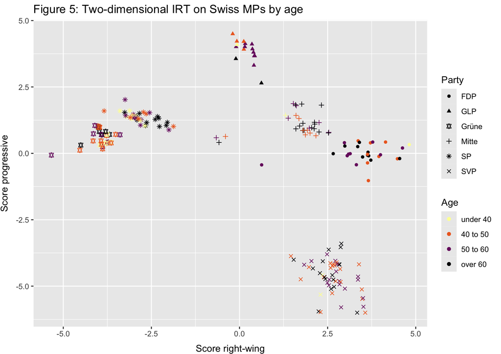

With regard to age and MPs’ ideal points, there are two possible hypotheses. Like men, older MPs might be more right wing and conservative. Or they might be more centrist. Looking at Figure 5, there is no clear pattern. I run equivalent models to those on gender. Table 2 shows that age has no influence on ideal points and dispersion overall. However, older SP and Mitte MPs are more right-wing compared to other parties and younger MPs.

| Table 2: Effect of age and party on progressiveness score, right-wing score and dispersion of MPs |  |  |  |  |  |  |
| --- | --- | --- | --- | --- | --- | --- |
|  | Progressive | Progressive | Right-wing | Right-wing | Dispersion | Dispersion |
| Intercept | -0.15 | -0.10 | 3.46 *** | 4.82 *** | 0.64 *** | 1.35 ** |
|  | (0.20) | (0.48) | (0.25) | (0.59) | (0.19) | (0.46) |
| Age | 0.00 | 0.00 | 0.00 | -0.02 * | -0.00 | -0.01 |
|  | (0.00) | (0.01) | (0.00) | (0.01) | (0.00) | (0.01) |
| Age * GLP |  | -0.04 * |  | 0.04 |  | 0.02 |
|  |  | (0.02) |  | (0.02) |  | (0.02) |
| Age * Grüne |  | 0.01 |  | 0.02 |  | 0.01 |
|  |  | (0.01) |  | (0.01) |  | (0.01) |
| Age * Mitte |  | 0.00 |  | 0.03 * |  | 0.01 |
|  |  | (0.01) |  | (0.01) |  | (0.01) |
| Age * SP |  | -0.01 |  | 0.04 ** |  | 0.02 |
|  |  | (0.01) |  | (0.01) |  | (0.01) |
| Age * SVP |  | 0.01 |  | 0.02 |  | 0.02 |
|  |  | (0.01) |  | (0.01) |  | (0.01) |
| N | 198 | 198 | 198 | 198 | 198 | 198 |
| R2 | 0.98 | 0.98 | 0.96 | 0.97 | 0.10 | 0.12 |
| *** p < 0.001; ** p < 0.01; * p < 0.05. |  |  |  |  |  |  |